# Challenge 9

Author

Hannah Pawig

**This is where the code lives**

```r
A_baby_names <- read_csv(here('supporting_artifacts',
                            'learning_targets',
                            'Challenge 9',
                            'StateNames_A.csv'))
```

# Dataset Preview

**This is where the code lives**

```r
head(A_baby_names, 50) |>
  datatable()
```

|  | Name | Year | Gender | State | Count |
| --- | --- | --- | --- | --- | --- |
| 1 | Ashley | 1997 | F | AK | 45 |
| 2 | Abigail | 1997 | F | AK | 32 |
| 3 | Alyssa | 1997 | F | AK | 32 |
| 4 | Amanda | 1997 | F | AK | 28 |
| 5 | Amber | 1997 | F | AK | 27 |
| 6 | Alexis | 1997 | F | AK | 25 |
| 7 | Alexandra | 1997 | F | AK | 20 |
| 8 | Anna | 1997 | F | AK | 20 |
| 9 | Allison | 1997 | F | AK | 19 |
| 10 | Alicia | 1997 | F | AK | 12 |

[output cut: 40 more lines]

# Summarizing & Visualizing the Number of Allisons

## 1. Summary Table

> Number of babies named “Allison” for each state and sex of the baby.

**This is where the code lives**

```r
A_baby_names |>
  rename(Sex = 'Gender') |>
  filter(Name == 'Allison') |>
  group_by(State, Sex) |>
  summarise(
    Num_Allisons = sum(Count)
  )  |>
  pivot_wider(
              names_from = Sex,
              values_from = Num_Allisons) |>
  mutate(
    across(.cols = 'F':'M',
           .fns = ~replace_na(., 0))
  ) |>
  datatable(caption = 'Babies named "Allison" in the US',
            colnames = c('Number of Females' = 'F',
                         'Number of Males' = 'M'),
            style = 'auto',
            editable = TRUE,
            class = c('cell-border', 'stripe'))
```

|  | State | Number of Females | Number of Males |
| --- | --- | --- | --- |
| 1 | AK | 232 | 0 |
| 2 | AL | 1535 | 0 |
| 3 | AR | 1198 | 0 |
| 4 | AZ | 1880 | 0 |
| 5 | CA | 12413 | 0 |
| 6 | CO | 1594 | 0 |
| 7 | CT | 1099 | 0 |
| 8 | DC | 321 | 0 |
| 9 | DE | 294 | 0 |
| 10 | FL | 4455 | 0 |

[output cut: 41 more lines]

## 2. Focusing on babies assigned as Female at birth

```r
Allisons <- A_baby_names |>
  rename(Sex = 'Gender') |>
  filter(Name == 'Allison',
         Sex == 'F') |>
  group_by(Year) |>
  summarise(Num_Allisons = sum(Count))
```

## 3. Visualization

**This is where the code lives**

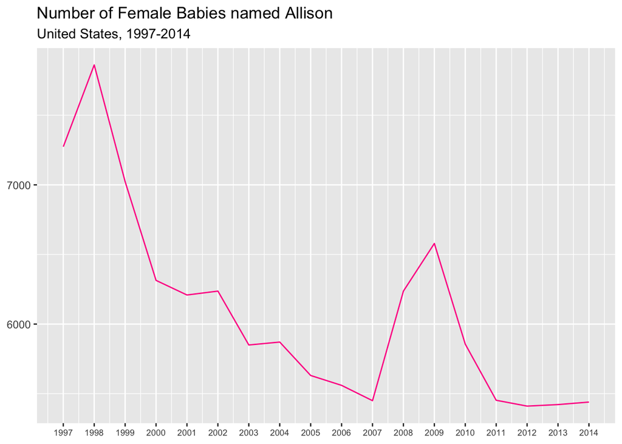

```r
Allisons |>
  ggplot(mapping = aes(x = Year,
                       y = Num_Allisons)) +
  geom_line(color = 'deeppink') +
  labs(title = 'Number of Female Babies named Allison',
       subtitle = 'United States, 1997-2014') +
  theme(axis.title.x = element_blank(),
        axis.title.y = element_blank(),
        axis.text.x = element_text(size = 7)) +
  scale_x_continuous(
    breaks = seq(from = 1997, to = 2014, by = 1)
  )
```

# Modeling the Number of Allisons

## 4. Creating a linear model with the year as the explanatory variable, and the number of Allisons as the response.

```r
lm_Allisons <- Allisons |>
  lm(formula = Num_Allisons ~ Year,
     data = _)
```

## 5. Visualize the Regression Model

**This is where the code lives**

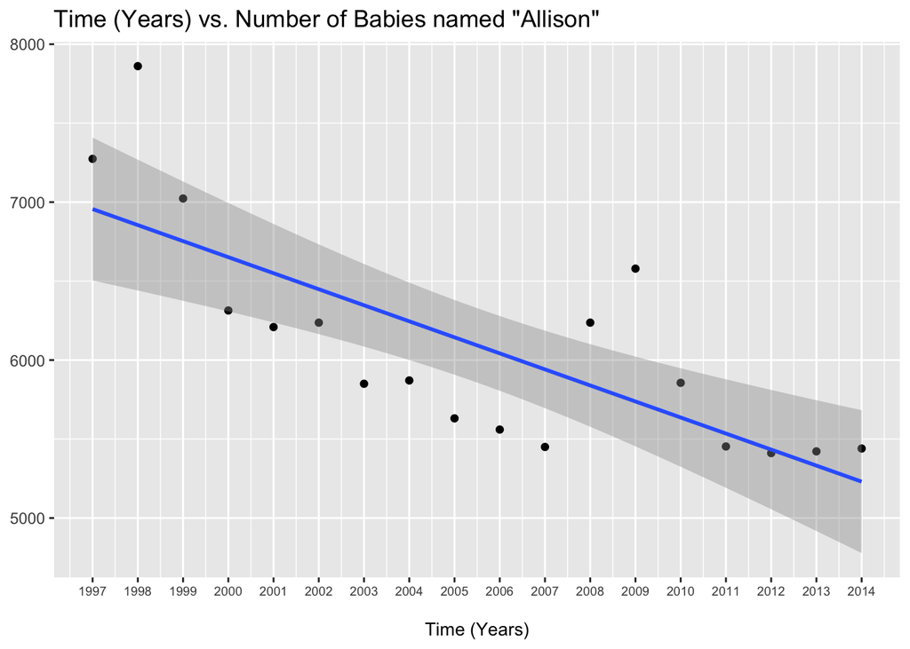

```r
lm_Allisons |>
  ggplot(mapping = aes(x = Year,
                       y = Num_Allisons)) +
  geom_point() +
  stat_smooth(method = 'lm') +
  labs(title = 'Time (Years) vs. Number of Babies named "Allison"',
       x = '\nTime (Years)') +
  theme(
    axis.title.y = element_blank(),
    axis.title.x = element_text(size = 10),
    axis.text.x = element_text(size = 7)
  ) +
  scale_x_continuous(
    breaks = seq(from = 1997, to = 2014, by = 1)
  )
```

## 6. The Estimated Regression Equation

**This is where the code lives**

```r
lm_Allisons
```

```
Call:
lm(formula = Num_Allisons ~ Year, data = Allisons)

Coefficients:
(Intercept)         Year
   209689.8       -101.5
```

Predicted number of babies named Allison = 209689.8 - 101.5(Year)

## 7. Plotting Residuals

**This is where the code lives**

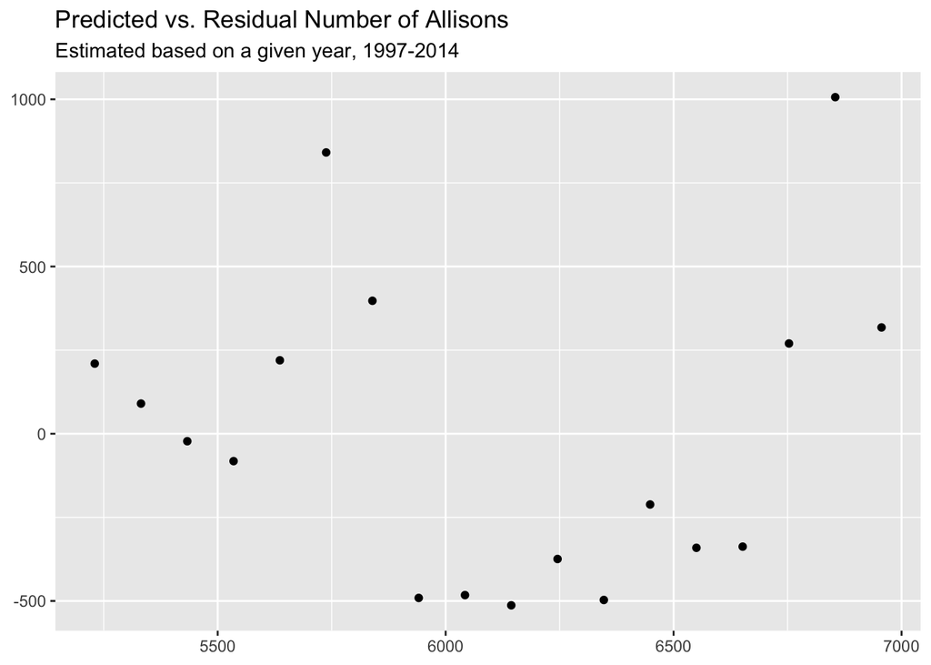

```r
lm_Allisons |>
  broom::augment() |>
  ggplot(mapping = aes(y = .resid, x = .fitted)) +
  geom_point() +
  labs(title = 'Predicted vs. Residual Number of Allisons',
       subtitle = 'Estimated based on a given year, 1997-2014') +
  theme(axis.title.x = element_blank(),
        axis.title.y = element_blank())
```

## 8. What can we conclude from the model?

Per year increase, there are 101 fewer Allisons than the previous year, and overall there is a downward trend for naming babies “Allison” from 1997 to 2014.

# Spelling by State

## 9. Finding the Allan/Alan/Allen babies

**This is where the code lives**

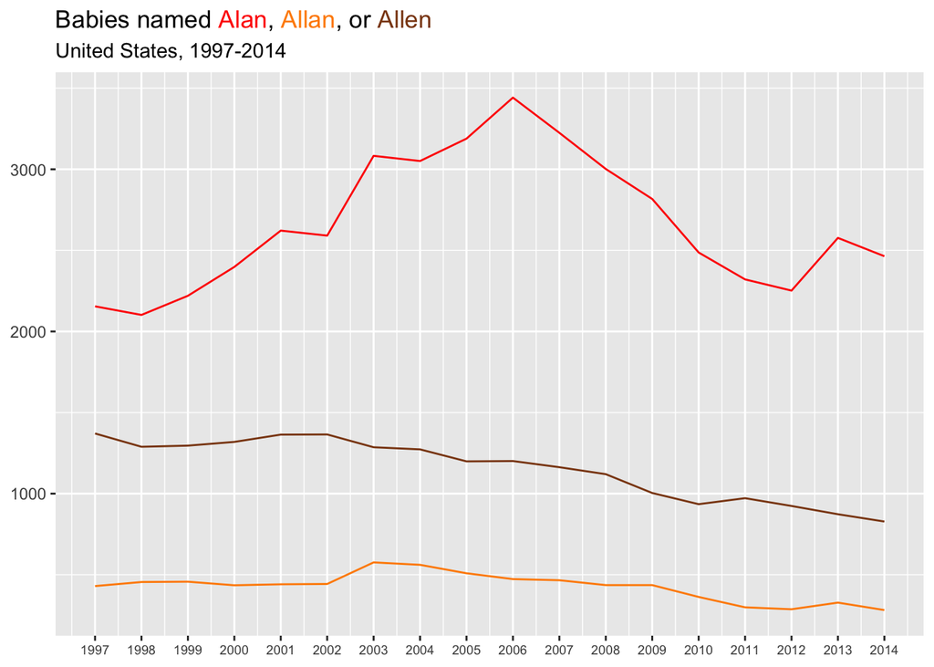

```r
Als <- A_baby_names |>
  filter(Name == 'Allen' | Name == 'Allan' | Name == 'Alan')


Als |>
  group_by(Year, Name) |>
  summarise(
    Num_Als = sum(Count)
  ) |>
  ggplot(mapping = aes(x = Year,
                       y = Num_Als,
                       color = Name)) +
  geom_line() +
  labs(title = "Babies named <span style='color:red'>Alan</span>, <span style='color
                :darkorange'>Allan</span>, or <span style='color:chocolate4'>Allen</span>",
       subtitle = 'United States, 1997-2014') +
  scale_color_manual(values = c('red', 'darkorange', 'chocolate4')) +
  theme(legend.position = 'none',
        plot.title = element_markdown(),
        axis.title.x = element_blank(),
        axis.title.y = element_blank(),
        axis.text.x = element_text(size = 7)) +
  scale_x_continuous(breaks = seq(from = 1997, to = 2014, by = 1))
```

## 10. The Allan babies in California and Pennsylvania (in 2000)

**This is where the code lives**

```r
Als |>
  filter(State == 'CA' | State == 'PA',
         Name == 'Allan',
         Year == 2000) |>
  group_by(State, Name) |>
  summarise(
    Count = sum(Count)
  ) |>
  mutate(
     Count = replace_na(Count, 0)
  )|>

  pivot_wider(names_from = State,
            values_from = Count) |>
  kable(align = 'ccc',
        caption = 'Number of Allan Babies in California & Pennsylvania (2000)') |>
  kable_material_dark()
```

Number of Allan Babies in California & Pennsylvania (2000)

| Name | CA | PA |
| --- | --- | --- |
| Allan | 131 | 12 |

## 11. Percentage Breakdown for the 3 spellings of Allan in CA & PA (2000)

**Creating a calculate_total function**

```r
calculate_total <- function(df, state, year) {
 df <- df |>
    filter(Year == {{ year }},
           State == {{ state }})
 total <- sum(df$Count)

  return(total)
}
```

**This is where the code lives**

```r
Als |>
  filter(State == 'CA' | State == 'PA',
         Year == 2000) |>
  group_by(State, Name) |>
    mutate(
     Count = replace_na(Count, 0),
     Total = case_when(
        State == 'CA' ~ calculate_total(df = Als, state = 'CA', year = 2000),
        State == 'PA' ~ calculate_total(df = Als, state = 'PA', year = 2000))
      ) |>
  summarise(
    Percentage = round((sum(Count) / mean(Total)) * 100,
                        digits = 2)) |>
  pivot_wider(names_from = Name,
            values_from = Percentage) |>
  kable(caption = 'Percentages of the different
        spellings across California & Pennsylvania (2000)') |>
  kable_material_dark(bootstrap_options = 'striped',
                html_font = 'Helvetica')
```

Percentages of the different spellings across California & Pennsylvania (2000)

| State | Alan | Allan | Allen |
| --- | --- | --- | --- |
| CA | 65.54 | 14.70 | 19.75 |
| PA | 42.86 | 10.08 | 47.06 |